# Risk Factor Analysis

## Outcome Variable

**Outcome Variable:** co_occurence

## Predictor Variables

**Intervention Variable:** ever_stunted06

**Adjustment Set:**

- sex
- arm
- brthmon
- single
- hhwealth_quart
- W_mage
- W_mhtcm
- W_meducyrs
- W_feducyrs
- delta_brthmon
- delta_single
- delta_hhwealth_quart
- delta_W_mage
- delta_W_mhtcm
- delta_W_meducyrs
- delta_W_feducyrs

## Stratifying Variables

The analysis was stratified on these variable(s):

- studyid
- country

## Data Summary

| studyid | country | ever_stunted06 | co_occurence | n_cell | n | outcome_variable |
| --- | --- | --- | --- | --- | --- | --- |
| CMC-V-BCS-2002 | INDIA | 0 | 0 | 171 | 366 | co_occurence |
| CMC-V-BCS-2002 | INDIA | 0 | 1 | 7 | 366 | co_occurence |
| CMC-V-BCS-2002 | INDIA | 1 | 0 | 173 | 366 | co_occurence |
| CMC-V-BCS-2002 | INDIA | 1 | 1 | 15 | 366 | co_occurence |
| CMIN | BANGLADESH | 0 | 0 | 95 | 237 | co_occurence |
| CMIN | BANGLADESH | 0 | 1 | 5 | 237 | co_occurence |
| CMIN | BANGLADESH | 1 | 0 | 116 | 237 | co_occurence |
| CMIN | BANGLADESH | 1 | 1 | 21 | 237 | co_occurence |
| COHORTS | GUATEMALA | 0 | 0 | 419 | 778 | co_occurence |
| COHORTS | GUATEMALA | 0 | 1 | 12 | 778 | co_occurence |
| COHORTS | GUATEMALA | 1 | 0 | 321 | 778 | co_occurence |
| COHORTS | GUATEMALA | 1 | 1 | 26 | 778 | co_occurence |
| COHORTS | PHILIPPINES | 0 | 0 | 1694 | 2487 | co_occurence |
| COHORTS | PHILIPPINES | 0 | 1 | 92 | 2487 | co_occurence |
| COHORTS | PHILIPPINES | 1 | 0 | 606 | 2487 | co_occurence |
| COHORTS | PHILIPPINES | 1 | 1 | 95 | 2487 | co_occurence |
| CONTENT | PERU | 0 | 0 | 172 | 200 | co_occurence |
| CONTENT | PERU | 0 | 1 | 0 | 200 | co_occurence |
| CONTENT | PERU | 1 | 0 | 28 | 200 | co_occurence |
| CONTENT | PERU | 1 | 1 | 0 | 200 | co_occurence |
| EE | PAKISTAN | 0 | 0 | 80 | 346 | co_occurence |
| EE | PAKISTAN | 0 | 1 | 8 | 346 | co_occurence |
| EE | PAKISTAN | 1 | 0 | 192 | 346 | co_occurence |
| EE | PAKISTAN | 1 | 1 | 66 | 346 | co_occurence |
| GMS-Nepal | NEPAL | 0 | 0 | 341 | 550 | co_occurence |
| GMS-Nepal | NEPAL | 0 | 1 | 29 | 550 | co_occurence |
| GMS-Nepal | NEPAL | 1 | 0 | 149 | 550 | co_occurence |
| GMS-Nepal | NEPAL | 1 | 1 | 31 | 550 | co_occurence |
| IRC | INDIA | 0 | 0 | 228 | 405 | co_occurence |
| IRC | INDIA | 0 | 1 | 3 | 405 | co_occurence |

[output cut: 78 more lines]

The following strata were considered:

- studyid: CMC-V-BCS-2002, country: INDIA
- studyid: CMIN, country: BANGLADESH
- studyid: COHORTS, country: GUATEMALA
- studyid: COHORTS, country: PHILIPPINES
- studyid: CONTENT, country: PERU
- studyid: EE, country: PAKISTAN
- studyid: GMS-Nepal, country: NEPAL
- studyid: IRC, country: INDIA
- studyid: JiVitA-4, country: BANGLADESH
- studyid: Keneba, country: GAMBIA
- studyid: LCNI-5, country: MALAWI
- studyid: MAL-ED, country: BANGLADESH
- studyid: MAL-ED, country: BRAZIL
- studyid: MAL-ED, country: INDIA
- studyid: MAL-ED, country: NEPAL
- studyid: MAL-ED, country: PERU
- studyid: MAL-ED, country: SOUTH AFRICA
- studyid: MAL-ED, country: TANZANIA, UNITED REPUBLIC OF
- studyid: NIH-Birth, country: BANGLADESH
- studyid: NIH-Crypto, country: BANGLADESH
- studyid: PROBIT, country: BELARUS
- studyid: PROVIDE, country: BANGLADESH
- studyid: ResPak, country: PAKISTAN
- studyid: SAS-CompFeed, country: INDIA
- studyid: SAS-FoodSuppl, country: INDIA
- studyid: TanzaniaChild2, country: TANZANIA, UNITED REPUBLIC OF
- studyid: ZVITAMBO, country: ZIMBABWE

### Dropped Strata

Some strata were dropped due to rare outcomes:

- studyid: CONTENT, country: PERU
- studyid: IRC, country: INDIA
- studyid: LCNI-5, country: MALAWI
- studyid: MAL-ED, country: BRAZIL
- studyid: MAL-ED, country: NEPAL
- studyid: MAL-ED, country: PERU
- studyid: MAL-ED, country: SOUTH AFRICA
- studyid: MAL-ED, country: TANZANIA, UNITED REPUBLIC OF
- studyid: PROBIT, country: BELARUS
- studyid: ResPak, country: PAKISTAN
- studyid: TanzaniaChild2, country: TANZANIA, UNITED REPUBLIC OF

## Methods Detail

We’re interested in the causal parameters $E[Y_a]$ for all values of $a \in \mathcal{A}$. These parameters represent the mean outcome if, possibly contrary to fact, we intervened to set all units to have $A=a$. Under the randomization and positivity assumptions, these are identified by the statistical parameters $\psi_a=E_W[E_{Y|A,W}(Y|A=a,W)]$. In addition, we’re interested in the mean of $Y$, $E[Y]$ under no intervention (the observed mean). We will estimate these parameters by using SuperLearner to fit the relevant likelihood factors – $E_{Y|A,W}(Y|A=a,W)$ and $p(A=a|W)$, and then updating our likelihood fit using a joint TMLE.

For unadjusted analyses ($W=\{\}$), initial likelihoods were estimated using Lrnr_glm to estimate the simple $E(Y|A)$ and Lrnr_mean to estimate $p(A)$. For adjusted analyses, a small library containing Lrnr_glmnet, Lrnr_xgboost, and Lrnr_mean was used.

Having estimated these parameters, we will then use the delta method to estimate relative risks and attributable risks relative to a prespecified baseline level of $A$.

[output not shown]

# Results Detail

## Results Plots

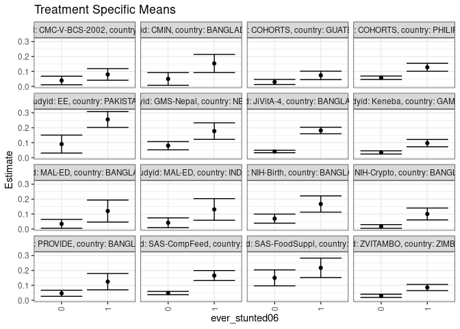

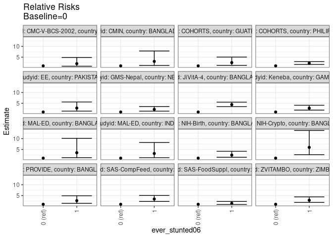

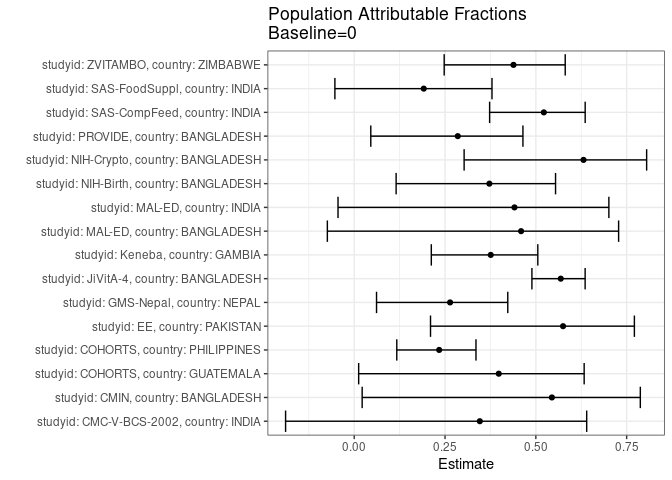

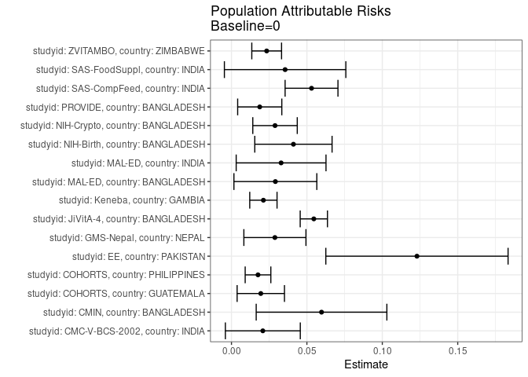

## Results Table

### Parameter: TSM

| studyid | country | intervention_level | baseline_level | estimate | ci_lower | ci_upper |
| --- | --- | --- | --- | --- | --- | --- |
| CMC-V-BCS-2002 | INDIA | 0 | NA | 0.0393258 | 0.0107329 | 0.0679188 |
| CMC-V-BCS-2002 | INDIA | 1 | NA | 0.0797872 | 0.0410013 | 0.1185732 |
| CMIN | BANGLADESH | 0 | NA | 0.0500000 | 0.0071932 | 0.0928068 |
| CMIN | BANGLADESH | 1 | NA | 0.1532847 | 0.0928308 | 0.2137385 |
| COHORTS | GUATEMALA | 0 | NA | 0.0294070 | 0.0121407 | 0.0466732 |
| COHORTS | GUATEMALA | 1 | NA | 0.0735447 | 0.0453107 | 0.1017786 |
| COHORTS | PHILIPPINES | 0 | NA | 0.0576031 | 0.0461663 | 0.0690399 |
| COHORTS | PHILIPPINES | 1 | NA | 0.1277817 | 0.1011003 | 0.1544631 |
| EE | PAKISTAN | 0 | NA | 0.0909091 | 0.0307581 | 0.1510601 |
| EE | PAKISTAN | 1 | NA | 0.2558140 | 0.2024965 | 0.3091314 |
| GMS-Nepal | NEPAL | 0 | NA | 0.0802980 | 0.0526897 | 0.1079064 |
| GMS-Nepal | NEPAL | 1 | NA | 0.1779450 | 0.1227705 | 0.2331194 |
| JiVitA-4 | BANGLADESH | 0 | NA | 0.0414178 | 0.0331798 | 0.0496558 |
| JiVitA-4 | BANGLADESH | 1 | NA | 0.1818831 | 0.1599841 | 0.2037821 |
| Keneba | GAMBIA | 0 | NA | 0.0351462 | 0.0244750 | 0.0458173 |
| Keneba | GAMBIA | 1 | NA | 0.0974654 | 0.0729807 | 0.1219501 |
| MAL-ED | BANGLADESH | 0 | NA | 0.0342466 | 0.0046802 | 0.0638130 |
| MAL-ED | BANGLADESH | 1 | NA | 0.1200000 | 0.0462887 | 0.1937113 |
| MAL-ED | INDIA | 0 | NA | 0.0416667 | 0.0089572 | 0.0743762 |
| MAL-ED | INDIA | 1 | NA | 0.1309524 | 0.0586519 | 0.2032529 |
| NIH-Birth | BANGLADESH | 0 | NA | 0.0693186 | 0.0389397 | 0.0996975 |
| NIH-Birth | BANGLADESH | 1 | NA | 0.1671249 | 0.1127391 | 0.2215107 |
| NIH-Crypto | BANGLADESH | 0 | NA | 0.0168675 | 0.0044682 | 0.0292668 |
| NIH-Crypto | BANGLADESH | 1 | NA | 0.1004566 | 0.0606121 | 0.1403012 |
| PROVIDE | BANGLADESH | 0 | NA | 0.0469833 | 0.0267488 | 0.0672179 |
| PROVIDE | BANGLADESH | 1 | NA | 0.1246991 | 0.0699846 | 0.1794137 |
| SAS-CompFeed | INDIA | 0 | NA | 0.0485916 | 0.0378379 | 0.0593453 |
| SAS-CompFeed | INDIA | 1 | NA | 0.1657067 | 0.1321528 | 0.1992607 |
| SAS-FoodSuppl | INDIA | 0 | NA | 0.1501956 | 0.0968466 | 0.2035447 |
| SAS-FoodSuppl | INDIA | 1 | NA | 0.2173307 | 0.1522893 | 0.2823721 |
| ZVITAMBO | ZIMBABWE | 0 | NA | 0.0298864 | 0.0192129 | 0.0405599 |
| ZVITAMBO | ZIMBABWE | 1 | NA | 0.0855340 | 0.0648409 | 0.1062270 |

### Parameter: E(Y)

| studyid | country | intervention_level | baseline_level | estimate | ci_lower | ci_upper |
| --- | --- | --- | --- | --- | --- | --- |
| CMC-V-BCS-2002 | INDIA | NA | NA | 0.0601093 | 0.0357249 | 0.0844936 |
| CMIN | BANGLADESH | NA | NA | 0.1097046 | 0.0698323 | 0.1495770 |
| COHORTS | GUATEMALA | NA | NA | 0.0488432 | 0.0336878 | 0.0639985 |
| COHORTS | PHILIPPINES | NA | NA | 0.0751910 | 0.0648251 | 0.0855569 |
| EE | PAKISTAN | NA | NA | 0.2138728 | 0.1706052 | 0.2571404 |
| GMS-Nepal | NEPAL | NA | NA | 0.1090909 | 0.0830130 | 0.1351688 |
| JiVitA-4 | BANGLADESH | NA | NA | 0.0960141 | 0.0859500 | 0.1060782 |
| Keneba | GAMBIA | NA | NA | 0.0563063 | 0.0455826 | 0.0670300 |
| MAL-ED | BANGLADESH | NA | NA | 0.0633484 | 0.0311604 | 0.0955364 |
| MAL-ED | INDIA | NA | NA | 0.0745614 | 0.0403897 | 0.1087331 |
| NIH-Birth | BANGLADESH | NA | NA | 0.1103896 | 0.0817833 | 0.1389959 |
| NIH-Crypto | BANGLADESH | NA | NA | 0.0457413 | 0.0294659 | 0.0620168 |
| PROVIDE | BANGLADESH | NA | NA | 0.0657194 | 0.0452330 | 0.0862057 |
| SAS-CompFeed | INDIA | NA | NA | 0.1016680 | 0.0902317 | 0.1131043 |
| SAS-FoodSuppl | INDIA | NA | NA | 0.1857585 | 0.1432798 | 0.2282372 |
| ZVITAMBO | ZIMBABWE | NA | NA | 0.0532229 | 0.0425206 | 0.0639253 |

### Parameter: RR

| studyid | country | intervention_level | baseline_level | estimate | ci_lower | ci_upper |
| --- | --- | --- | --- | --- | --- | --- |
| CMC-V-BCS-2002 | INDIA | 0 | 0 | 1.000000 | 1.0000000 | 1.000000 |
| CMC-V-BCS-2002 | INDIA | 1 | 0 | 2.028875 | 0.8460862 | 4.865149 |
| CMIN | BANGLADESH | 0 | 0 | 1.000000 | 1.0000000 | 1.000000 |
| CMIN | BANGLADESH | 1 | 0 | 3.065693 | 1.1944241 | 7.868626 |
| COHORTS | GUATEMALA | 0 | 0 | 1.000000 | 1.0000000 | 1.000000 |
| COHORTS | GUATEMALA | 1 | 0 | 2.500927 | 1.2393082 | 5.046878 |
| COHORTS | PHILIPPINES | 0 | 0 | 1.000000 | 1.0000000 | 1.000000 |
| COHORTS | PHILIPPINES | 1 | 0 | 2.218313 | 1.6639855 | 2.957305 |
| EE | PAKISTAN | 0 | 0 | 1.000000 | 1.0000000 | 1.000000 |
| EE | PAKISTAN | 1 | 0 | 2.813954 | 1.4061838 | 5.631080 |
| GMS-Nepal | NEPAL | 0 | 0 | 1.000000 | 1.0000000 | 1.000000 |
| GMS-Nepal | NEPAL | 1 | 0 | 2.216057 | 1.3953096 | 3.519583 |
| JiVitA-4 | BANGLADESH | 0 | 0 | 1.000000 | 1.0000000 | 1.000000 |
| JiVitA-4 | BANGLADESH | 1 | 0 | 4.391424 | 3.4854872 | 5.532828 |
| Keneba | GAMBIA | 0 | 0 | 1.000000 | 1.0000000 | 1.000000 |
| Keneba | GAMBIA | 1 | 0 | 2.773145 | 1.8732297 | 4.105386 |
| MAL-ED | BANGLADESH | 0 | 0 | 1.000000 | 1.0000000 | 1.000000 |
| MAL-ED | BANGLADESH | 1 | 0 | 3.504000 | 1.2145141 | 10.109406 |
| MAL-ED | INDIA | 0 | 0 | 1.000000 | 1.0000000 | 1.000000 |
| MAL-ED | INDIA | 1 | 0 | 3.142857 | 1.2036923 | 8.206043 |
| NIH-Birth | BANGLADESH | 0 | 0 | 1.000000 | 1.0000000 | 1.000000 |
| NIH-Birth | BANGLADESH | 1 | 0 | 2.410968 | 1.3957167 | 4.164719 |
| NIH-Crypto | BANGLADESH | 0 | 0 | 1.000000 | 1.0000000 | 1.000000 |
| NIH-Crypto | BANGLADESH | 1 | 0 | 5.955642 | 2.5832749 | 13.730509 |
| PROVIDE | BANGLADESH | 0 | 0 | 1.000000 | 1.0000000 | 1.000000 |
| PROVIDE | BANGLADESH | 1 | 0 | 2.654113 | 1.4344926 | 4.910669 |
| SAS-CompFeed | INDIA | 0 | 0 | 1.000000 | 1.0000000 | 1.000000 |
| SAS-CompFeed | INDIA | 1 | 0 | 3.410193 | 2.3041207 | 5.047225 |
| SAS-FoodSuppl | INDIA | 0 | 0 | 1.000000 | 1.0000000 | 1.000000 |
| SAS-FoodSuppl | INDIA | 1 | 0 | 1.446984 | 0.9140170 | 2.290726 |
| ZVITAMBO | ZIMBABWE | 0 | 0 | 1.000000 | 1.0000000 | 1.000000 |
| ZVITAMBO | ZIMBABWE | 1 | 0 | 2.861970 | 1.8589700 | 4.406135 |

### Parameter: PAR

| studyid | country | intervention_level | baseline_level | estimate | ci_lower | ci_upper |
| --- | --- | --- | --- | --- | --- | --- |
| CMC-V-BCS-2002 | INDIA | 0 | NA | 0.0207834 | -0.0040547 | 0.0456216 |
| CMIN | BANGLADESH | 0 | NA | 0.0597046 | 0.0163932 | 0.1030160 |
| COHORTS | GUATEMALA | 0 | NA | 0.0194362 | 0.0037399 | 0.0351326 |
| COHORTS | PHILIPPINES | 0 | NA | 0.0175879 | 0.0090858 | 0.0260900 |
| EE | PAKISTAN | 0 | NA | 0.1229637 | 0.0625503 | 0.1833772 |
| GMS-Nepal | NEPAL | 0 | NA | 0.0287929 | 0.0082138 | 0.0493719 |
| JiVitA-4 | BANGLADESH | 0 | NA | 0.0545963 | 0.0455565 | 0.0636361 |
| Keneba | GAMBIA | 0 | NA | 0.0211601 | 0.0121132 | 0.0302071 |
| MAL-ED | BANGLADESH | 0 | NA | 0.0291018 | 0.0016205 | 0.0565832 |
| MAL-ED | INDIA | 0 | NA | 0.0328947 | 0.0031265 | 0.0626629 |
| NIH-Birth | BANGLADESH | 0 | NA | 0.0410710 | 0.0154501 | 0.0666919 |
| NIH-Crypto | BANGLADESH | 0 | NA | 0.0288739 | 0.0141307 | 0.0436170 |
| PROVIDE | BANGLADESH | 0 | NA | 0.0187360 | 0.0041046 | 0.0333674 |
| SAS-CompFeed | INDIA | 0 | NA | 0.0530764 | 0.0355542 | 0.0705986 |
| SAS-FoodSuppl | INDIA | 0 | NA | 0.0355629 | -0.0046986 | 0.0758243 |
| ZVITAMBO | ZIMBABWE | 0 | NA | 0.0233365 | 0.0134692 | 0.0332039 |

### Parameter: PAF

| studyid | country | intervention_level | baseline_level | estimate | ci_lower | ci_upper |
| --- | --- | --- | --- | --- | --- | --- |
| CMC-V-BCS-2002 | INDIA | 0 | NA | 0.3457610 | -0.1889189 | 0.6399849 |
| CMIN | BANGLADESH | 0 | NA | 0.5442308 | 0.0218796 | 0.7876278 |
| COHORTS | GUATEMALA | 0 | NA | 0.3979310 | 0.0122501 | 0.6330174 |
| COHORTS | PHILIPPINES | 0 | NA | 0.2339095 | 0.1171993 | 0.3351902 |
| EE | PAKISTAN | 0 | NA | 0.5749386 | 0.2100556 | 0.7712786 |
| GMS-Nepal | NEPAL | 0 | NA | 0.2639348 | 0.0614525 | 0.4227336 |
| JiVitA-4 | BANGLADESH | 0 | NA | 0.5686280 | 0.4892020 | 0.6357037 |
| Keneba | GAMBIA | 0 | NA | 0.3758042 | 0.2122374 | 0.5054089 |
| MAL-ED | BANGLADESH | 0 | NA | 0.4593933 | -0.0739341 | 0.7278645 |
| MAL-ED | INDIA | 0 | NA | 0.4411765 | -0.0445806 | 0.7010439 |
| NIH-Birth | BANGLADESH | 0 | NA | 0.3720553 | 0.1153701 | 0.5542604 |
| NIH-Crypto | BANGLADESH | 0 | NA | 0.6312422 | 0.3025665 | 0.8050247 |
| PROVIDE | BANGLADESH | 0 | NA | 0.2850912 | 0.0456310 | 0.4644686 |
| SAS-CompFeed | INDIA | 0 | NA | 0.5220561 | 0.3727584 | 0.6358175 |
| SAS-FoodSuppl | INDIA | 0 | NA | 0.1914468 | -0.0531898 | 0.3792588 |
| ZVITAMBO | ZIMBABWE | 0 | NA | 0.4384677 | 0.2476670 | 0.5808791 |